# tugas1

### Metode DMA

Metode pemulusan Double Moving Average (DMA) pada dasarnya mirip dengan SMA. Namun demikian, metode ini lebih cocok digunakan untuk pola data trend. Proses pemulusan dengan rata rata dalam metode ini dilakukan sebanyak 2 kali.

```r
data.sma <- SMA(train_ma.ts, n=4)

dma <- SMA(data.sma, n = 4)
At <- 2*data.sma - dma
Bt <- 2/(4-1)*(data.sma - dma)
data.dma<- At+Bt
data.ramal2<- c(NA, data.dma)

t = 1:41
f = c()

for (i in t) {
  f[i] = At[length(At)] + Bt[length(Bt)]*(i)
}

data.gab2 <- cbind(aktual = c(train_ma.ts,rep(NA,41)), pemulusan1 = c(data.sma,rep(NA,41)),pemulusan2 = c(data.dma, rep(NA,41)),At = c(At, rep(NA,41)), Bt = c(Bt,rep(NA,41)),ramalan = c(data.ramal2, f[-1]))
data.gab2
```

```
##        aktual pemulusan1 pemulusan2       At         Bt  ramalan
##   [1,]  13700         NA         NA       NA         NA       NA
##   [2,]  13700         NA         NA       NA         NA       NA
##   [3,]  13700         NA         NA       NA         NA       NA
##   [4,]  13650    13687.5         NA       NA         NA       NA
##   [5,]  13700    13687.5         NA       NA         NA       NA
##   [6,]  13700    13687.5         NA       NA         NA       NA
##   [7,]  13700    13687.5   13687.50 13687.50   0.000000       NA
##   [8,]  13700    13700.0   13715.62 13709.38   6.250000 13687.50
##   [9,]  13700    13700.0   13710.42 13706.25   4.166667 13715.62
##  [10,]  13700    13700.0   13705.21 13703.12   2.083333 13710.42
##  [11,]  13700    13700.0   13700.00 13700.00   0.000000 13705.21
##  [12,]  13700    13700.0   13700.00 13700.00   0.000000 13700.00
##  [13,]  13750    13712.5   13728.12 13721.88   6.250000 13700.00
##  [14,]  13700    13712.5   13722.92 13718.75   4.166667 13728.12
```

[output cut: 92 more lines]

### Visualisasi

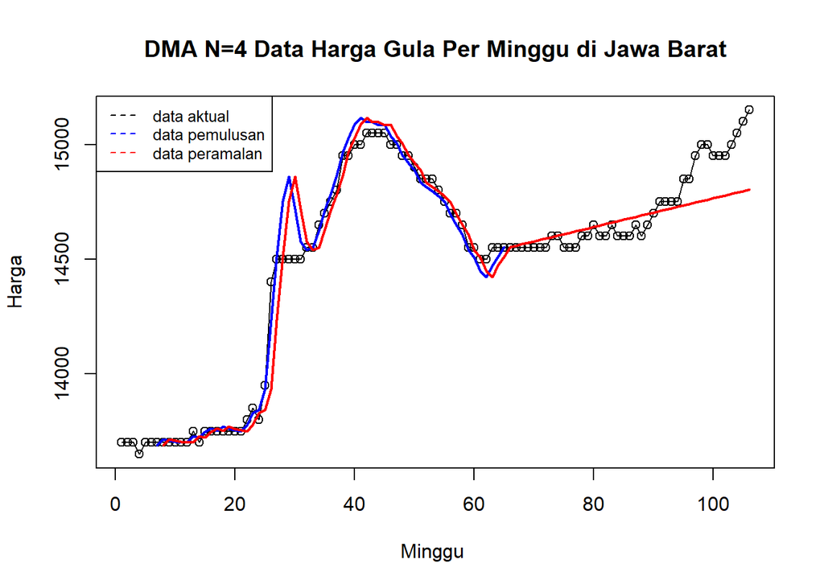

```r
ts.plot(data.ts, xlab="Minggu ", ylab="Harga", main= "DMA N=4 Data Harga Gula Per Minggu di Jawa Barat")
points(data.ts)
lines(data.gab2[,3],col="blue",lwd=2)
lines(data.gab2[,6],col="red",lwd=2)
legend("topleft",c("data aktual","data pemulusan","data peramalan"), lty=8, col=c("black","blue","red"), cex=0.8)
```

### Akurasi Data Latih

```r
error_train.dma = train_ma.ts-data.ramal2[1:length(train_ma.ts)]
SSE_train.dma = sum(error_train.dma[8:length(train_ma.ts)]^2)
MSE_train.dma = mean(error_train.dma[8:length(train_ma.ts)]^2)
MAPE_train.dma = mean(abs((error_train.dma[8:length(train_ma.ts)]/train_ma.ts[8:length(train_ma.ts)])*100))

akurasi_train.dma <- matrix(c(SSE_train.dma, MSE_train.dma, MAPE_train.dma))
row.names(akurasi_train.dma)<- c("SSE", "MSE", "MAPE")
colnames(akurasi_train.dma) <- c("Akurasi m = 4")
akurasi_train.dma
```

```
##      Akurasi m = 4
## SSE   6.489714e+05
## MSE   1.118916e+04
## MAPE  4.125129e-01
```

#Perhitungan akurasi menggunakan data latih menghasilkan nilai MAPE yang kurang dari 10% sehingga nilai akurasi ini dapat dikategorikan sebagai sangat baik.

### Akurasi Data Uji

```r
error_test.dma = test_ma.ts-data.gab2[66:106,6]
SSE_test.dma = sum(error_test.dma^2)
MSE_test.dma = mean(error_test.dma^2)
MAPE_test.dma = mean(abs((error_test.dma/test_ma.ts*100)))

akurasi_test.dma <- matrix(c(SSE_test.dma, MSE_test.dma, MAPE_test.dma))
row.names(akurasi_test.dma)<- c("SSE", "MSE", "MAPE")
colnames(akurasi_test.dma) <- c("Akurasi m = 4")
akurasi_test.dma
```

```
##      Akurasi m = 4
## SSE   6.625879e+05
## MSE   1.616068e+04
## MAPE  5.943042e-01
```

#Perhitungan akurasi menggunakan data uji menghasilkan nilai MAPE yang kurang dari 10% sehingga nilai akurasi ini dapat dikategorikan sebagai sangat baik.

## Double Exponential Smoothing (DES)

Metode Exponential Smoothing adalah metode pemulusan dengan melakukan pembobotan menurun secara eksponensial. Nilai yang lebih baru diberi bobot yang lebih besar dari nilai terdahulu. Terdapat satu atau lebih parameter pemulusan yang ditentukan secara eksplisit dan hasil pemilihan parameter tersebut akan menentukan bobot yang akan diberikan pada nilai pengamatan.

### Pembagian Data

Pembagian data latih dan data uji dilakukan dengan perbandingan 61% data latih dan 39% data uji.

```r
#membagi 61% data latih (training) dan 39% data uji (testing)
training <- data[1:65,]
testing  <- data[66:106,]
train.ts <- ts(training$Harga)
test.ts  <- ts(testing$Harga)
```

### Eksplorasi Data

Eksplorasi dilakukan dengan membuat plot data deret waktu untuk keseluruhan data, data latih, dan data uji.

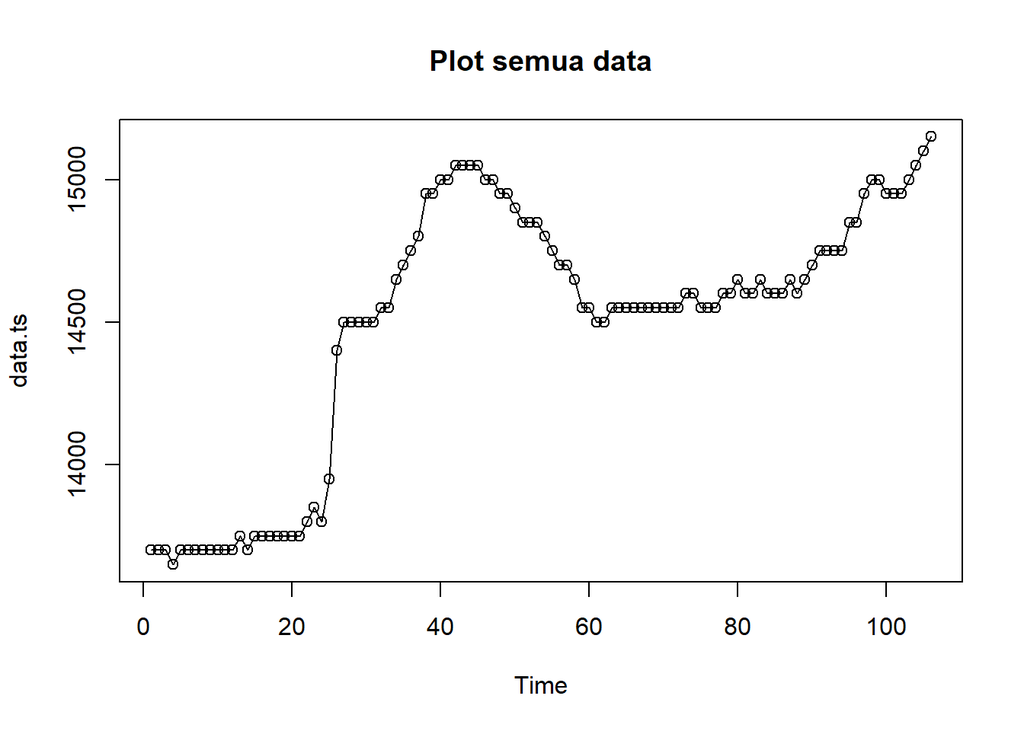

```r
#eksplorasi data
plot(data.ts, col="black",main="Plot semua data")
points(data.ts)
```

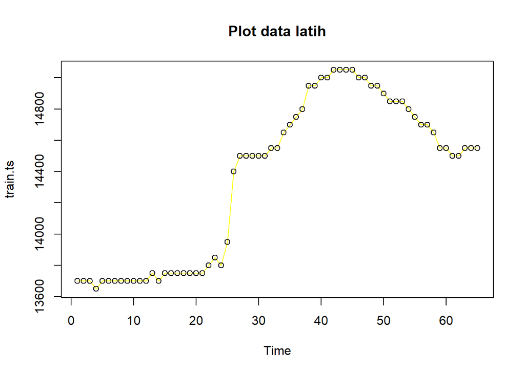

```r
plot(train.ts, col="yellow",main="Plot data latih")
points(train.ts)
```

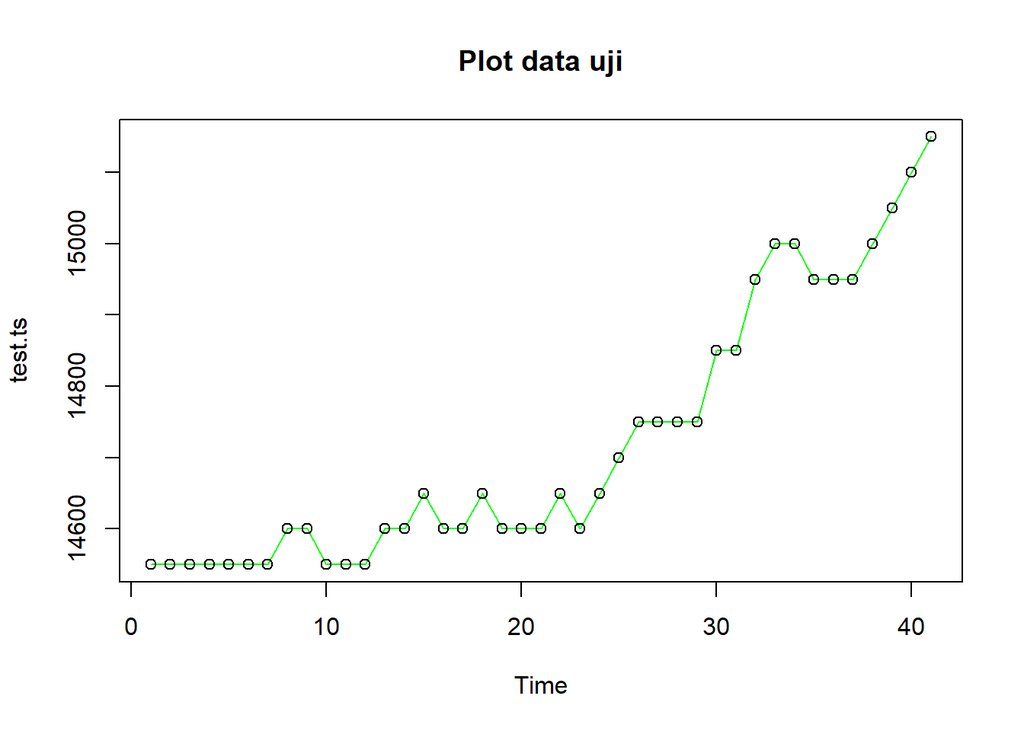

```r
plot(test.ts, col="green",main="Plot data uji")
points(test.ts)
```

Eksplorasi data juga dapat dilakukan menggunakan package `ggplot2` .

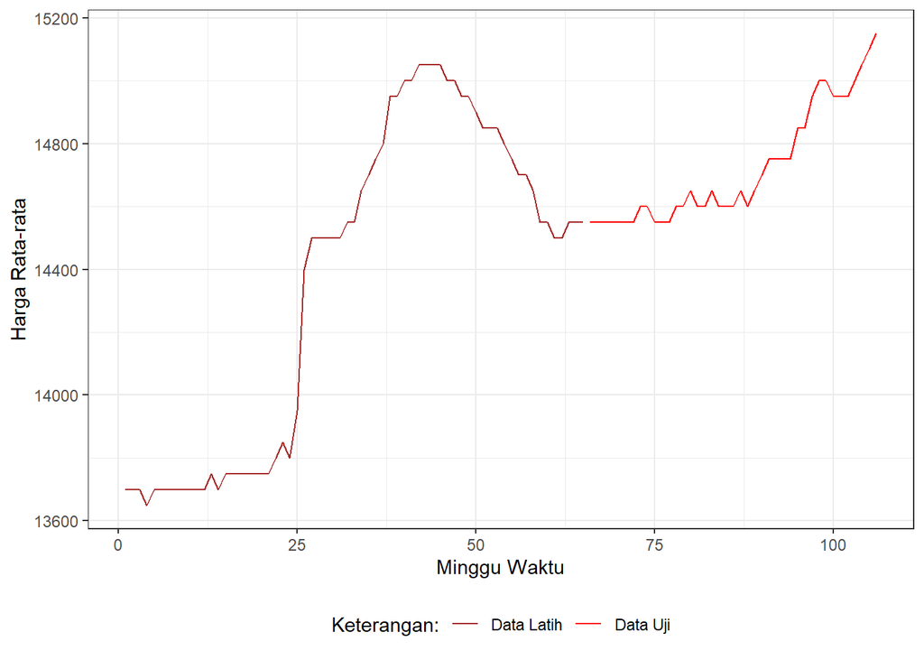

```r
#Eksplorasi dengan GGPLOT
library(ggplot2)
ggplot() +
  geom_line(data = training, aes(x = Minggu, y = Harga, col = "Data Latih")) +
  geom_line(data = testing, aes(x = Minggu, y = Harga, col = "Data Uji")) +
  labs(x = "Minggu Waktu", y = "Harga Rata-rata", color = "Legend") +
  scale_colour_manual(name="Keterangan:", breaks = c("Data Latih", "Data Uji"),
                      values = c("brown", "red")) +
  theme_bw() + theme(legend.position = "bottom",
                     plot.caption = element_text(hjust=0.5, size=12))
```

### Metode DES

#Metode pemulusan DES digunakan untuk data yang memiliki pola tren. Metode DES adalah metode semacam SES, hanya saja dilakukan dua kali, yaitu pertama untuk tahapan ‘level’ dan kedua untuk tahapan ‘tren’. Pemulusan menggunakan metode ini akan menghasilkan peramalan tidak konstan untuk Minggu berikutnya.

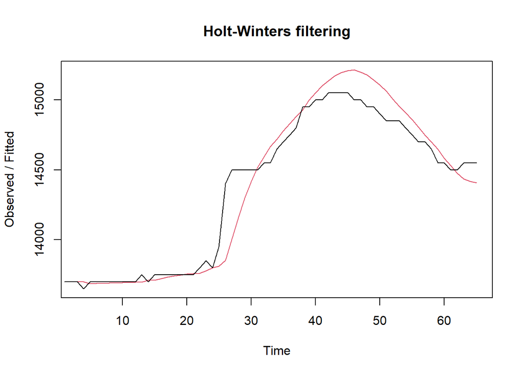

```r
#beta=0.2 dan alpha=0.2
des.1<- HoltWinters(train.ts, gamma = FALSE, beta = 0.2, alpha = 0.2)
plot(des.1)
```

```r
#ramalan
ramalandes1<- forecast(des.1, h=41)
ramalandes1
```

```
##     Point Forecast    Lo 80    Hi 80    Lo 95    Hi 95
##  66       14404.96 14222.54 14587.38 14125.98 14683.95
##  67       14374.30 14186.70 14561.90 14087.39 14661.21
##  68       14343.63 14149.20 14538.06 14046.28 14640.99
##  69       14312.97 14109.96 14515.97 14002.50 14623.43
##  70       14282.30 14068.94 14495.66 13955.99 14608.61
##  71       14251.64 14026.14 14477.13 13906.77 14596.50
##  72       14220.97 13981.62 14460.32 13854.91 14587.03
##  73       14190.31 13935.44 14445.17 13800.52 14580.09
##  74       14159.64 13887.70 14431.59 13743.74 14575.55
##  75       14128.98 13838.48 14419.48 13684.69 14573.26
##  76       14098.31 13787.88 14408.75 13623.54 14573.08
##  77       14067.65 13735.98 14399.31 13560.41 14574.88
##  78       14036.98 13682.88 14391.08 13495.43 14578.53
##  79       14006.32 13628.64 14383.99 13428.71 14583.92
```

[output cut: 27 more lines]

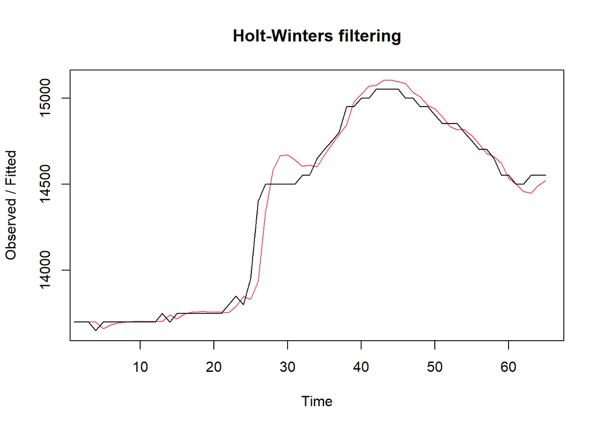

```r
#beta=0.3 dan aplha=0.6
des.2<- HoltWinters(train.ts, gamma = FALSE, beta = 0.3, alpha = 0.6)
plot(des.2)
```

```r
#ramalan
ramalandes2<- forecast(des.2, h=41)
ramalandes2
```

```
##     Point Forecast    Lo 80    Hi 80     Lo 95    Hi 95
##  66       14537.20 14429.99 14644.41 14373.239 14701.16
##  67       14536.15 14400.19 14672.12 14328.212 14744.09
##  68       14535.10 14364.58 14705.63 14274.307 14795.90
##  69       14534.06 14324.26 14743.86 14213.194 14854.92
##  70       14533.01 14279.94 14786.07 14145.975 14920.04
##  71       14531.96 14232.12 14831.80 14073.394 14990.52
##  72       14530.91 14181.13 14880.69 13995.974 15065.85
##  73       14529.86 14127.24 14932.49 13914.100 15145.62
##  74       14528.81 14070.62 14987.00 13828.071 15229.55
##  75       14527.76 14011.45 15044.08 13738.125 15317.40
##  76       14526.72 13949.84 15103.59 13644.459 15408.97
##  77       14525.67 13885.91 15165.43 13547.238 15504.10
##  78       14524.62 13819.75 15229.49 13446.607 15602.63
##  79       14523.57 13751.43 15295.71 13342.691 15704.45
```

[output cut: 27 more lines]

Nilai `y` adalah nilai data deret waktu, `gamma` adalah parameter pemulusan untuk komponen musiman, `beta` adalah parameter pemulusan untuk tren, dan `alpha` adalah parameter pemulusan untuk stasioner, serta `h` adalah banyaknya Minggu yang akan diramalkan.

### Visualisasi

Selanjutnya jika ingin membandingkan plot data latih dan data uji adalah sebagai berikut.

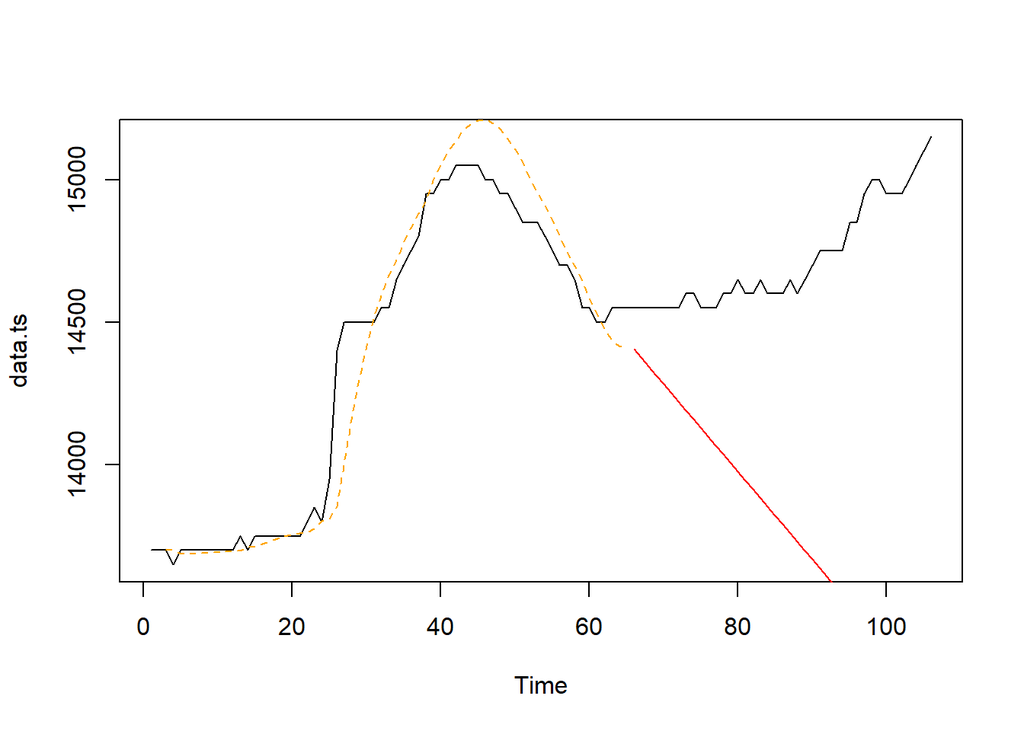

```r
#Visually evaluate the prediction
plot(data.ts)
lines(des.1$fitted[,1], lty=2, col="orange")
lines(ramalandes1$mean, col="red")
```

Untuk mendapatkan nilai parameter optimum dari DES, argumen `alpha` dan `beta` dapat dibuat `NULL` seperti berikut.

```r
#Lamda dan gamma optimum
des.opt<- HoltWinters(train.ts, gamma = FALSE)
des.opt
```

```
## Holt-Winters exponential smoothing with trend and without seasonal component.
##
## Call:
## HoltWinters(x = train.ts, gamma = FALSE)
##
## Smoothing parameters:
##  alpha: 1
##  beta : 0.1770138
##  gamma: FALSE
##
## Coefficients:
##          [,1]
## a 14550.00000
## b   -10.73672
```

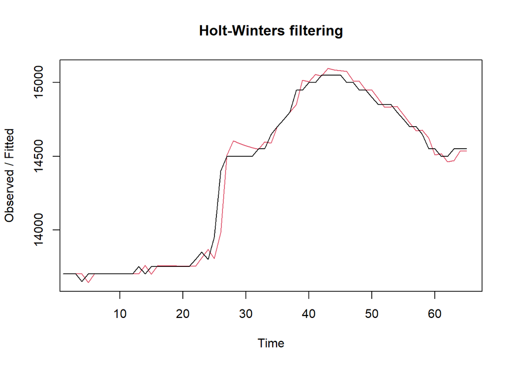

```r
plot(des.opt)
```

```r
#ramalan
ramalandesopt<- forecast(des.opt, h=41)
ramalandesopt
```

```
##     Point Forecast    Lo 80    Hi 80     Lo 95    Hi 95
##  66       14539.26 14448.93 14629.60 14401.105 14677.42
##  67       14528.53 14389.00 14668.05 14315.146 14741.91
##  68       14517.79 14332.24 14703.34 14234.018 14801.56
##  69       14507.05 14275.63 14738.48 14153.119 14860.99
##  70       14496.32 14218.17 14774.46 14070.926 14921.71
##  71       14485.58 14159.44 14811.72 13986.796 14984.36
##  72       14474.84 14099.25 14850.43 13900.430 15049.26
##  73       14464.11 14037.51 14890.70 13811.690 15116.52
##  74       14453.37 13974.18 14932.56 13720.517 15186.22
##  75       14442.63 13909.25 14976.01 13626.897 15258.37
##  76       14431.90 13842.73 15021.06 13530.842 15332.95
##  77       14421.16 13774.63 15067.69 13432.378 15409.94
##  78       14410.42 13704.98 15115.87 13331.538 15489.31
##  79       14399.69 13633.80 15165.58 13228.359 15571.01
```

[output cut: 27 more lines]

### Akurasi Data Latih

```r
#Akurasi Data Training
ssedes.train1<-des.1$SSE
msedes.train1<-ssedes.train1/length(train.ts)
sisaandes1<-ramalandes1$residuals
head(sisaandes1)
```

```
## Time Series:
## Start = 1
## End = 6
## Frequency = 1
## [1]     NA     NA   0.00 -50.00  12.00  11.12
```

```r
mapedes.train1 <- sum(abs(sisaandes1[3:length(train.ts)]/train.ts[3:length(train.ts)])
                      *100)/length(train.ts)

akurasides.1 <- matrix(c(ssedes.train1,msedes.train1,mapedes.train1))
row.names(akurasides.1)<- c("SSE", "MSE", "MAPE")
colnames(akurasides.1) <- c("Akurasi lamda=0.2 dan gamma=0.2")
akurasides.1
```

```
##      Akurasi lamda=0.2 dan gamma=0.2
## SSE                     1.265543e+06
## MSE                     1.946989e+04
## MAPE                    6.210092e-01
```

```r
ssedes.train2<-des.2$SSE
msedes.train2<-ssedes.train2/length(train.ts)
sisaandes2<-ramalandes2$residuals
head(sisaandes2)
```

```
## Time Series:
## Start = 1
## End = 6
## Frequency = 1
## [1]     NA     NA   0.00 -50.00  39.00  17.58
```

```r
mapedes.train2 <- sum(abs(sisaandes2[3:length(train.ts)]/train.ts[3:length(train.ts)])
                      *100)/length(train.ts)

akurasides.2 <- matrix(c(ssedes.train2,msedes.train2,mapedes.train2))
row.names(akurasides.2)<- c("SSE", "MSE", "MAPE")
colnames(akurasides.2) <- c("Akurasi lamda=0.6 dan gamma=0.3")
akurasides.2
```

```
##      Akurasi lamda=0.6 dan gamma=0.3
## SSE                     4.338883e+05
## MSE                     6.675204e+03
## MAPE                    3.303591e-01
```

Hasil akurasi dari data latih didapatkan skenario 2 dengan lamda=0.6 dan gamma=0.3 memiliki hasil yang lebih baik. Hal tersebut dapat dilihat berdasarkan nilai SSE, MSE,dan MAPE nya yang bernilai lebih kecil. Namun, kedua skenario tersebut dapat dikategorikan peramalan sangat baik berdasarkan nilai MAPE-nya.

### Akurasi Data Uji

```r
#Akurasi Data Testing
selisihdes1 <- ramalandes1$mean - testing$Harga
selisihdes1
```

```
## Time Series:
## Start = 66
## End = 106
## Frequency = 1
##  [1]  -145.0380  -175.7030  -206.3681  -237.0331  -267.6982  -298.3633
##  [7]  -329.0283  -409.6934  -440.3585  -421.0235  -451.6886  -482.3537
## [13]  -563.0187  -593.6838  -674.3488  -655.0139  -685.6790  -766.3440
## [19]  -747.0091  -777.6742  -808.3392  -889.0043  -869.6693  -950.3344
## [25] -1030.9995 -1111.6645 -1142.3296 -1172.9947 -1203.6597 -1334.3248
## [31] -1364.9899 -1495.6549 -1576.3200 -1606.9850 -1587.6501 -1618.3152
## [37] -1648.9802 -1729.6453 -1810.3104 -1890.9754 -1971.6405
```

```r
SSEtestingdes1<-sum(selisihdes1^2)
MSEtestingdes1<-SSEtestingdes1/length(testing$Harga)
MAPEtestingdes1<-sum(abs(selisihdes1/testing$Harga)*100)/length(testing$Harga)

selisihdes2<-ramalandes2$mean-testing$Harga
selisihdes2
```

```
## Time Series:
## Start = 66
## End = 106
## Frequency = 1
##  [1]  -12.79957  -13.84801  -14.89646  -15.94490  -16.99335  -18.04179
##  [7]  -19.09023  -70.13868  -71.18712  -22.23557  -23.28401  -24.33245
## [13]  -75.38090  -76.42934 -127.47778  -78.52623  -79.57467 -130.62312
## [19]  -81.67156  -82.72000  -83.76845 -134.81689  -85.86534 -136.91378
## [25] -187.96222 -239.01067 -240.05911 -241.10755 -242.15600 -343.20444
## [31] -344.25289 -445.30133 -496.34977 -497.39822 -448.44666 -449.49511
## [37] -450.54355 -501.59199 -552.64044 -603.68888 -654.73732
```

```r
SSEtestingdes2<-sum(selisihdes2^2)
MSEtestingdes2<-SSEtestingdes2/length(testing$Harga)
MAPEtestingdes2<-sum(abs(selisihdes2/testing$Harga)*100)/length(testing$Harga)

selisihdesopt<-ramalandesopt$mean-testing$Harga
selisihdesopt
```

```
## Time Series:
## Start = 66
## End = 106
## Frequency = 1
##  [1]   -10.73672   -21.47344   -32.21017   -42.94689   -53.68361   -64.42033
##  [7]   -75.15705  -135.89378  -146.63050  -107.36722  -118.10394  -128.84066
## [13]  -189.57739  -200.31411  -261.05083  -221.78755  -232.52427  -293.26100
## [19]  -253.99772  -264.73444  -275.47116  -336.20788  -296.94460  -357.68133
## [25]  -418.41805  -479.15477  -489.89149  -500.62821  -511.36494  -622.10166
## [31]  -632.83838  -743.57510  -804.31182  -815.04855  -775.78527  -786.52199
## [37]  -797.25871  -857.99543  -918.73216  -979.46888 -1040.20560
```

```r
SSEtestingdesopt<-sum(selisihdesopt^2)
MSEtestingdesopt<-SSEtestingdesopt/length(testing$Harga)
MAPEtestingdesopt<-sum(abs(selisihdesopt/testing$Harga)*100)/length(testing$Harga)

akurasitestingdes <-
  matrix(c(SSEtestingdes1,MSEtestingdes1,MAPEtestingdes1,SSEtestingdes2,MSEtestingdes2,
           MAPEtestingdes2,SSEtestingdesopt,MSEtestingdesopt,MAPEtestingdesopt),
         nrow=3,ncol=3)
row.names(akurasitestingdes)<- c("SSE", "MSE", "MAPE")
colnames(akurasitestingdes) <- c("des ske1","des ske2","des opt")
akurasitestingdes
```

```
##          des ske1     des ske2      des opt
## SSE  4.723896e+07 3.287069e+06 1.025738e+07
## MSE  1.152170e+06 8.017243e+04 2.501800e+05
## MAPE 6.276898e+00 1.381311e+00 2.674876e+00
```

# Perbandingan Metode Pemulusan DMA dan DES

```r
perbandingan <-
  matrix(c(SSE_test.dma, MSE_test.dma, MAPE_test.dma, SSEtestingdesopt,MSEtestingdesopt,MAPEtestingdesopt),
         nrow=3,ncol=2)
row.names(perbandingan)<- c("SSE", "MSE", "MAPE")
colnames(perbandingan) <- c("DMA","DES")
perbandingan
```

```
##               DMA          DES
## SSE  6.625879e+05 1.025738e+07
## MSE  1.616068e+04 2.501800e+05
## MAPE 5.943042e-01 2.674876e+00
```

Kedua metode dapat dibandingkan dengan menggunakan ukuran akurasi yang sama. Berdasarkan nilai SSE, MSE, dan MAPE, metode DMA lebih baik karena memiliki ukuran akurasi yang lebih kecil dibandingkan dengan metode DES. Berdasarkan nilai MAPE nya kedua metode tersebut memberikan peramalan dengan akurasi yang sangat baik karena kurang dari 10%